# Practical Machine Learning Project

Sudhir Ghiya

Friday, April 08, 2016

# **Human Activity Recognition**

## Executive Summary

### Details of Weight Lifting Exercises Dataset

Six young health participants were asked to perform one set of 10 repetitions of the Unilateral Dumbbell Biceps Curl in five different fashions: exactly according to the specification (Class A), throwing the elbows to the front (Class B), lifting the dumbbell only halfway (Class C), lowering the dumbbell only halfway (Class D) and throwing the hips to the front (Class E).

Read more: (http://groupware.les.inf.puc-rio.br/har#ixzz44vlDAJfT)

## Project Instructions

One thing that people regularly do is quantify how much of a particular activity they do, but they rarely quantify how well they do it. In this project, your goal will be to use data from accelerometers on the belt, forearm, arm, and dumbell of 6 participants.  
The goal of your project is to predict the manner in which they did the exercise. This is the “classe” variable in the training set. You may use any of the other variables to predict with. You should create a report describing how you built your model, how you used cross validation, what you think the expected out of sample error is, and why you made the choices you did. You will also use your prediction model to predict 20 different test cases.

### Load of Libraries Required

```r
library(lattice, quietly = TRUE, warn.conflicts=FALSE);
library(ggplot2, quietly = TRUE, warn.conflicts=FALSE);
library(caret, quietly = TRUE, warn.conflicts=FALSE);
library(kernlab, quietly = TRUE, warn.conflicts=FALSE);

# libraries for train
library(randomForest, quietly=TRUE, warn.conflicts=FALSE) # w/ method = "rf"
library(arm, quietly=TRUE, warn.conflicts=FALSE)        # w/ method = "bayesglm"
library(MASS, quietly=TRUE, warn.conflicts=FALSE)       #
library(Matrix, quietly=TRUE, warn.conflicts=FALSE)     # required by lme4
library(lme4, quietly=TRUE, warn.conflicts=FALSE)       # w/ method = "lmer", "glmer", "nlmer"
library(caTools, quietly=TRUE, warn.conflicts=FALSE)    # w/ method = ""
library(rpart, quietly=TRUE, warn.conflicts=FALSE)      # w/ method = "rpart"
library(nnet, quietly=TRUE, warn.conflicts=FALSE)       # w/ method = "nnet"

# libraries for Parallel Processing
library(foreach, warn.conflicts=FALSE)
library(iterators, warn.conflicts=FALSE)
library(parallel, warn.conflicts=FALSE);
library(doParallel, warn.conflicts=FALSE);

# get # Cores in CPU and activate Parallel Clusters
cluster <- makeCluster(detectCores());
registerDoParallel(cluster);
```

### Getting and Cleaning Data

We will now read in the Training and Test Data Set.

```r
set.seed(12345)

if (file.exists("pml-training.csv")) {
  dataset <- read.csv("pml-training.csv", na.strings=c("NA","#DIV/0!",""))
} else {
  download.file("http://d396qusza40orc.cloudfront.net/predmachlearn/pml-training.csv","pml-training.csv")
  dataset <- read.csv("pml-training.csv", na.strings=c("NA","#DIV/0!",""))
}

if (file.exists("pml-testing.csv")) {
  testing <- read.csv("pml-testing.csv", na.strings=c("NA","#DIV/0!",""))
} else {
  download.file("http://d396qusza40orc.cloudfront.net/predmachlearn/pml-testing.csv","pml-testing.csv")
  testing <- read.csv("pml-testing.csv", na.strings=c("NA","#DIV/0!",""))
}

#
# We will remove first 7 cols which are X, user_name, raw_timestamp_part_1,
# raw_timestamp_part_2, cvtd_timestamp, new_window, num_window
#
dataset<-dataset[,8:160]
testing<-testing[,8:160]

# Remove Columns where not much data is available to perform worthwile analysis

# get #rows and use it to

all_data <- apply(!is.na(dataset),2,sum) > dim(dataset)[1]-1

dataset<-dataset[,all_data]
testing<-testing[,all_data]
```

```r
dim(training)
```

[output not shown]

### Creation of Partion to do Training

Now partition the dataset into a smaller set [training] to improve the the model build.

```r
InTrain<-createDataPartition(y=dataset$classe,p=0.3,list=FALSE)
training<-dataset[InTrain,]
```

### Correlation Analysis

We have the following columns/attributes which suggest a high degree of Co-Relation amongst them.

```r
correlation <- findCorrelation(cor(training[, 1:52]), cutoff=0.80)
correlationMatrix <- data.frame(cor(training[, 1:52]))
names(training)[correlation]
```

```
##  [1] "accel_belt_z"     "roll_belt"        "accel_belt_y"
##  [4] "accel_dumbbell_z" "accel_belt_x"     "pitch_belt"
##  [7] "accel_dumbbell_x" "accel_arm_x"      "magnet_arm_y"
## [10] "magnet_belt_z"    "gyros_arm_x"
```

### Model Generation

Now use the Method “RandomForest” to generate the Train Model. (See Appendix for further Models tested and Accuracy results)

```r
# Set PCA
tC <- trainControl(method="cv", number=5, verboseIter=F, preProcOptions="pca", allowParallel=T)
# Train Model (Random Forest)
fit.rf        <- train(classe ~ ., data = training, method="rf", prox=TRUE,allowParallel=TRUE)
save(fit.rf, file="fit_rf.RData")
```

### Confusion Matrix for Model (Random Forest) being used.

We get a good accuracy of approx 97.70% using the Random Forest.

```r
print(fit.rf)
```

[output not shown]

```r
print(fit.rf$finalModel)
```

```
##
## Call:
##  randomForest(x = x, y = y, mtry = param$mtry, proximity = TRUE,      allowParallel = TRUE)
##                Type of random forest: classification
##                      Number of trees: 500
## No. of variables tried at each split: 27
##
##         OOB estimate of  error rate: 2.24%
## Confusion matrix:
##      A    B   C   D    E class.error
## A 1666    3   3   0    2 0.004778973
## B   25 1093  20   1    1 0.041228070
## C    1   23 994   8    1 0.032132425
## D    0    3  23 935    4 0.031088083
## E    1    3   4   6 1069 0.012927054
```

### Required Project Outcome

#### Predictions for test data set (20 recordings)

```r
rfPred <- predict(fit.rf, test)
rfPred
```

```
##  [1] B A B A A E D B A A B C B A E E A B B B
## Levels: A B C D E
```

# Appendix

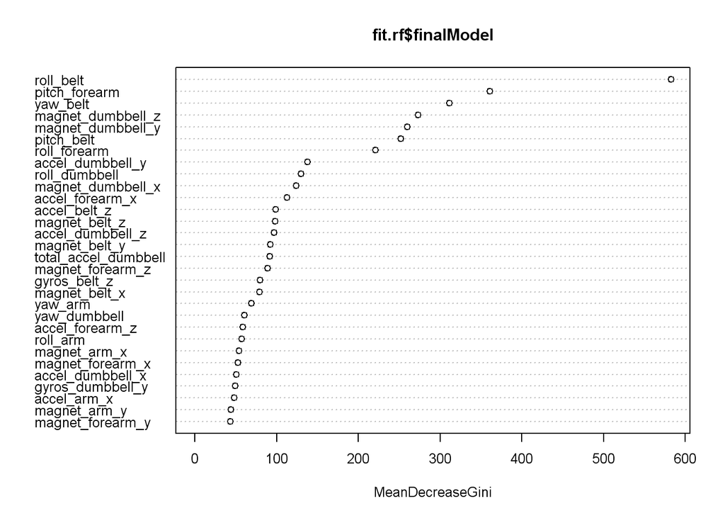

```r
varImpPlot(fit.rf$finalModel, sort=TRUE, cex = 0.8)
```

### Pre-Processing & Cross Validation Settings (for Other Models) tried out

```r
# Pre-Processing & Cross Validation Settings
tC <- trainControl(method="cv", number=5, verboseIter=F, preProcOptions="pca", allowParallel=T)

# Other Models tried out.
# ---- svmRadial
fit.svmr       <- train(classe ~ ., data = training, trControl=tC, verbose=FALSE, method = "svmRadial")
save(fit.svmr, file="fit_svmr.RData")

# ---- nnet
fit.NN         <- train(classe ~ ., data = training, trControl=tC, verbose=FALSE, method = "nnet")
save(fit.NN, file="fit_NN.RData")

# ---- svmLinear
fit.svml       <- train(classe ~ ., data = training, trControl=tC, verbose=FALSE, method = "svmLinear")
save(fit.svml, file="fit_svml.RData")

# ---- LogitBoost
fit.logitboost <- train(classe ~ ., data = training, trControl=tC, verbose=FALSE, method = "LogitBoost")
save(fit.logitboost, file="fit_logitboost.RData")

# ---- bayesglm
# fit.bayesglm   <- train(classe ~ ., data = training, trControl=tC, verbose=FALSE, method = "bayesglm")
# save(fit.bayesglm, file="fit_bayesglm.RData")
#
# # ---- rpart
# fit.rpart      <- train(classe ~ ., data = training, trControl=tC, verbose=FALSE, method = "rpart")
# save(fit.rpart, file="fit_rpart.RData")
```

### Comparing Model Accuracy

On Comparing the Model’s Acurracy, have concluded the Random Forest gives a decent result.

```r
model <- c("Random Forest", "SVM (radial)","LogitBoost","SVM (linear)","Neural Net") # ,"bayesglm", "rpart"
Accuracy <- c( max(fit.rf$results$Accuracy)
              ,max(fit.svmr$results$Accuracy)
              ,max(fit.logitboost$results$Accuracy)
              ,max(fit.svml$results$Accuracy)
              ,max(fit.NN$results$Accuracy))
            # ,max(fit.bayesglm$results$Accuracy))
            # ,max(fit.rpart$results$Accuracy))

Kappa <- c( max(fit.rf$results$Kappa)
           ,max(fit.svmr$results$Kappa)
           ,max(fit.logitboost$results$Kappa)
           ,max(fit.svml$results$Kappa)
           ,max(fit.NN$results$Kappa))
           # ,max(fit.bayesglm$results$Kappa)
           # ,max(fit.rpart$results$Kappa))

performance <- cbind(model,Accuracy,Kappa)
performance
```

```
##      model           Accuracy            Kappa
## [1,] "Random Forest" "0.977077906121211" "0.971000458463433"
## [2,] "SVM (radial)"  "0.88350768871565"  "0.85233952558632"
## [3,] "LogitBoost"    "0.889261452594842" "0.859235116775855"
## [4,] "SVM (linear)"  "0.767706306355688" "0.704629919190448"
## [5,] "Neural Net"    "0.405843985057918" "0.242486971244326"
```

### Citations

The data for this project come from this source: http://groupware.les.inf.puc-rio.br/har.